# Day 15: Decision Trees — In-Class Activity (Solutions)

Is this college private? A tree of yes/no questions

Instructor

```r
data(College)
College <- College %>%
  mutate(tuition = Outstate / 1000, undergrad = F.Undergrad / 1000)

# Day 14's folds: every college gets a fold number from 1 to 5
set.seed(122)
College <- College %>%
  mutate(fold = sample(rep(1:5, length.out = n())))
```

## Part 1: Grow and Read a Tree

### Task 1.1: Grow it

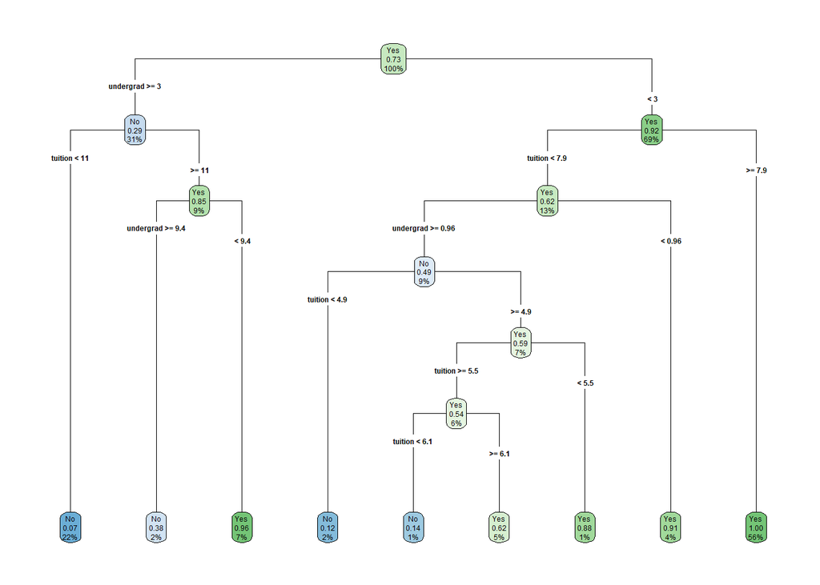

```r
tree <- rpart(Private ~ tuition + undergrad, data = College, method = "class")
rpart.plot(tree, type = 4, extra = 106)
```

The first question is **`undergrad >= 3`**: does the college have about 3,000 or more full-time undergrads? Big colleges go left (mostly public), small ones go right (mostly private). The tree has **9 leaves**.

### Task 1.2: Follow a college down the tree

```r
new_college <- tibble(tuition = 6, undergrad = 1.5)

predict(tree, new_college, type = "prob")
```

```
##          No       Yes
## 1 0.8571429 0.1428571
```

```r
predict(tree, new_college, type = "class")
```

```
##  1
## No
## Levels: No Yes
```

The trace: undergrad 1.5 is **not** ≥ 3, so go right. Tuition 6 is < 7.9, so go left. Undergrad 1.5 is ≥ 0.96, so go left. Tuition 6 is not < 4.9, so go right. Tuition 6 is ≥ 5.5, so go left. Tuition 6 is < 6.1, so go left, into a leaf whose share private is **0.14**. The tree predicts **No** (not private), and `predict()` agrees.

Only 7 of the 777 colleges land in that leaf, and the leaves on either side of it (tuition just below 5.5 or just above 6.1) predict private. A prediction that flips back and forth over a few hundred dollars of tuition, based on a handful of colleges, is fitting noise. That’s a sign the tree may be too big, which is Day 16’s topic.

## Part 2: Score the Tree with CV

### Task 2.1: Same folds, new method

```r
errors <- rep(NA, 5)

for (f in 1:5) {
  train <- College %>% filter(fold != f)
  test  <- College %>% filter(fold == f)
  # The method: a decision tree with rpart's default settings
  fit <- rpart(Private ~ tuition + undergrad, data = train, method = "class")
  pred <- predict(fit, test, type = "class")
  errors[f] <- mean(pred != test$Private)
}

errors
```

```
## [1] 0.08974359 0.10256410 0.05806452 0.07096774 0.09032258
```

```r
mean(errors)
```

```
## [1] 0.08233251
```

```r
sd(errors) / sqrt(5)
```

```
## [1] 0.007893593
```

The tree’s CV error is **8.2%**, with an SE of **0.8%**. That is 1.4 points worse than logistic regression (6.8%) and 2.2 points worse than the best KNN (K = 5, 6.0%). Both gaps are bigger than the SE of about 0.8 points, so the tree really is worse here, though not by a lot. With these two predictors, the boundary between public and private runs diagonally (cheap and big vs expensive and small), and a tree can only draw it as a staircase of rectangles. On the slides the true rule *was* a staircase, so the tree’s rectangles fit it well. No method wins on every dataset.

## Part 3: Grow It All the Way

### Task 3.1: No stopping rule

```r
no_stopping <- rpart.control(cp = 0, minsplit = 2, minbucket = 1)
full_tree <- rpart(Private ~ tuition + undergrad, data = College,
                   method = "class", control = no_stopping)

sum(full_tree$frame$var == "<leaf>")   # number of leaves
```

```
## [1] 66
```

```r
mean(predict(full_tree, College, type = "class") != College$Private)
```

```
## [1] 0
```

The full tree has **66 leaves** and a training error of **0%**. It’s like **KNN with K = 1**: it keeps splitting until each leaf holds colleges of a single class, so every training college is predicted by a leaf built around itself (and a few identical neighbors). Like K = 1, the 0% says nothing about new colleges.

### Task 3.2: CV the full tree

```r
errors <- rep(NA, 5)

for (f in 1:5) {
  train <- College %>% filter(fold != f)
  test  <- College %>% filter(fold == f)
  # The method: a tree grown until every leaf is pure
  fit <- rpart(Private ~ tuition + undergrad, data = train, method = "class",
               control = no_stopping)
  pred <- predict(fit, test, type = "class")
  errors[f] <- mean(pred != test$Private)
}

mean(errors)
```

```
## [1] 0.09526882
```

```r
sd(errors) / sqrt(5)
```

```
## [1] 0.006670914
```

The full tree’s CV error is **9.5%** (SE 0.7%), worse than the default tree’s 8.2%. Its last splits carve out tiny boxes around one or two training colleges, often unusual ones (a cheap private college, an expensive public one). Those boxes are noise: a new college that falls into one gets the label of the odd college the box was built around, not the label its neighborhood usually has. Low bias, high variance (Day 9).

## Part 4: All the Predictors

### Task 4.1: Let the tree choose

```r
college_all <- College %>% select(-tuition, -undergrad)
```

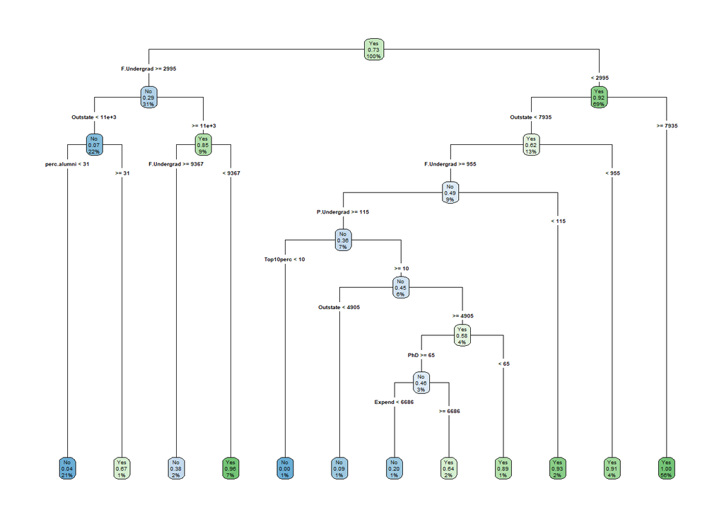

```r
tree_all <- rpart(Private ~ . - fold, data = college_all, method = "class")
rpart.plot(tree_all, type = 4, extra = 106)
```

```r
errors <- rep(NA, 5)
for (f in 1:5) {
  train <- college_all %>% filter(fold != f)
  test  <- college_all %>% filter(fold == f)
  # The method: a default tree with all 17 predictors
  fit <- rpart(Private ~ . - fold, data = train, method = "class")
  pred <- predict(fit, test, type = "class")
  errors[f] <- mean(pred != test$Private)
}
mean(errors)
```

```
## [1] 0.08490488
```

```r
sd(errors) / sqrt(5)
```

```
## [1] 0.01018459
```

The tree uses **7 of the 17 predictors**: F.Undergrad, Outstate, perc.alumni, P.Undergrad, Top10perc, PhD, Expend. The top of the tree is the same as before (`F.Undergrad`, then `Outstate`); the other predictors only appear in small boxes lower down. The CV error is **8.5%** (SE 1.0%) vs 8.2% with two predictors. Within one SE, so the extra predictors didn’t help. **No standardizing.** A split asks “is `Outstate` < 10,674?” Changing the units just changes the cutoff (10.674 in thousands), and the same colleges go each way. Distances don’t enter anywhere, so no predictor can dominate because of its units, unlike KNN.

## Bonus

### Bonus 1: A different sample

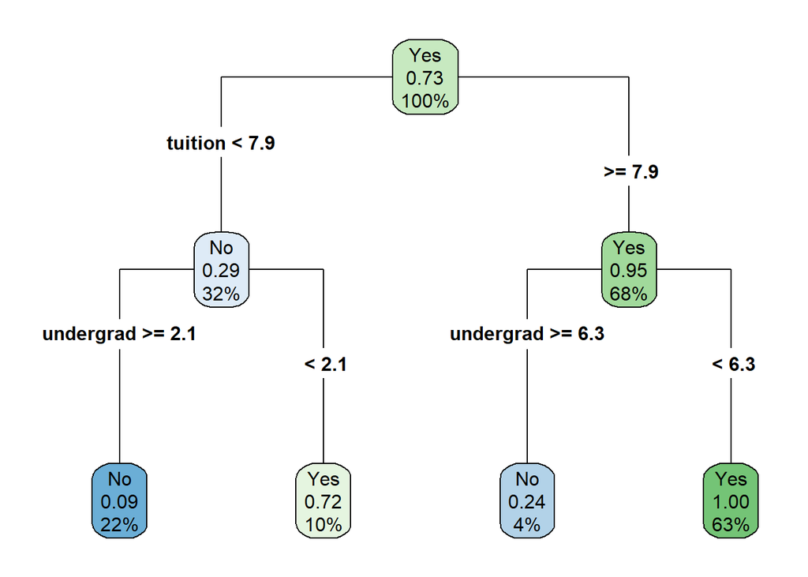

```r
set.seed(15)
half <- sample(nrow(College), nrow(College) / 2)
tree_a <- rpart(Private ~ tuition + undergrad, data = College %>% slice(half), method = "class")
tree_b <- rpart(Private ~ tuition + undergrad, data = College %>% slice(-half), method = "class")
rpart.plot(tree_a, type = 4, extra = 106)
```

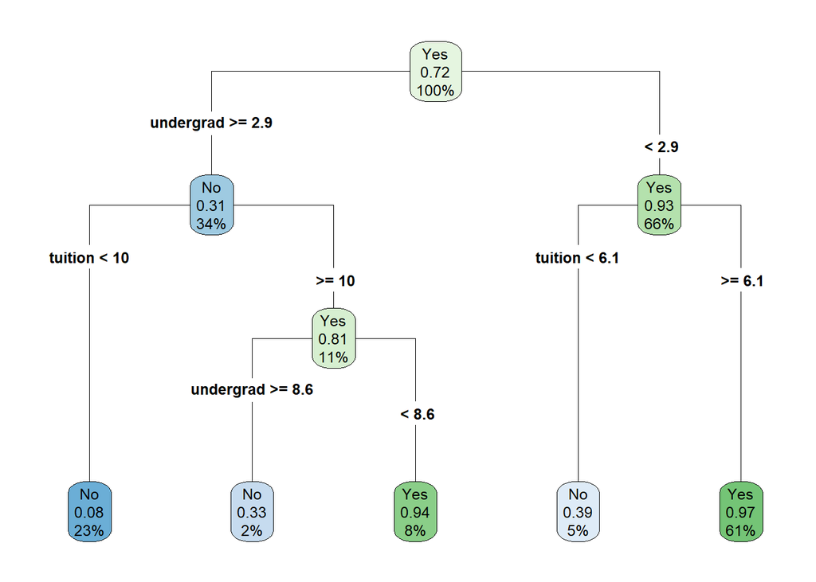

```r
rpart.plot(tree_b, type = 4, extra = 106)
```

No: one half starts with tuition, the other with undergrad. Both predictors split the colleges almost equally well at the top (see the slides’ impurity curves), so a different sample can flip which one wins, and everything below the root changes with it. The exact cutoffs in one tree aren’t worth much on their own.

### Bonus 2: Check the root split by hand

```r
gini <- function(p) 2 * p * (1 - p)
p_all <- mean(College$Private == "Yes")
gini(p_all)
```

```
## [1] 0.3968006
```

```r
split_impurity <- function(goes_left) {
  sides <- College %>%
    mutate(left = goes_left) %>%
    group_by(left) %>%
    summarize(n = n(), G = gini(mean(Private == "Yes")))
  sum(sides$n * sides$G) / nrow(College)   # average G, weighted by size
}
split_impurity(College$undergrad >= root_cut)   # the root split
```

```
## [1] 0.2253072
```

```r
split_impurity(College$tuition < 10)            # another cutoff
```

```
## [1] 0.2940716
```

The root split lowers the impurity from 0.397 to 0.225. `tuition < 10` leaves 0.294, which is worse, as the tree says.

### Bonus 3: A regression tree

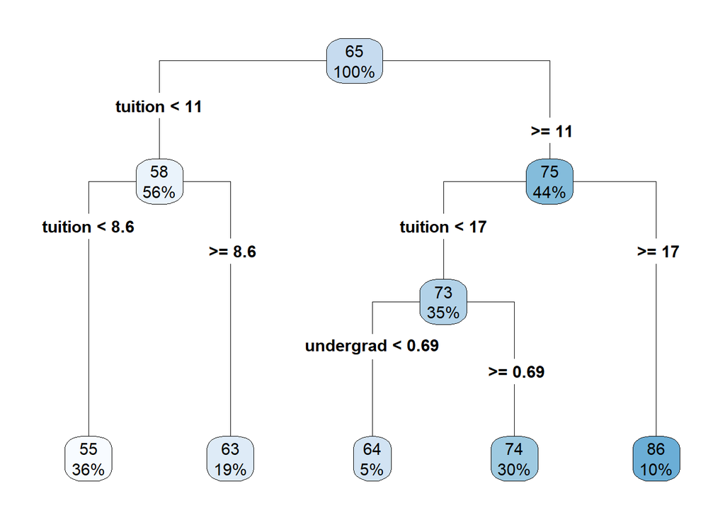

```r
grad_tree <- rpart(Grad.Rate ~ tuition + undergrad, data = College)
rpart.plot(grad_tree, type = 4)
```

Each leaf now predicts the **average graduation rate** of its colleges, not a class. The tree splits mostly on tuition, and the highest leaf is the most expensive colleges, at about 86%. This describes graduation rates; it doesn’t mean tuition causes them.